# Тест #8

## Вариант #4

**Журавский Максим, группа 520**

```r
library(TSA)
library(aTSA)
library(tidyverse)
library(tseries)
library(lmtest)
library(bsts)
```

### Исследование исходного временного ряда

Считаем файл с данными и отсортируем данные от старых к новым. Перейдем к дифференцированному ряду.

```r
df %>% head()
```

```
## # A tibble: 6 x 3
##   Date       Amount    Inc
##   <date>      <dbl>  <dbl>
## 1 2015-06-10  0.865 -2.91
## 2 2015-06-17  0.114 -0.751
## 3 2015-06-24  1.84   1.72
## 4 2015-07-01  0.392 -1.44
## 5 2015-07-08  1.64   1.25
## 6 2015-07-15  3.82   2.18
```

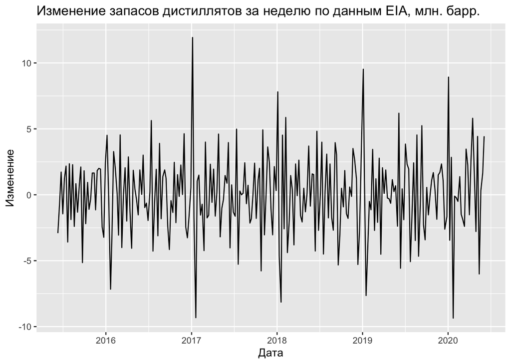

Для исключения интервенции, связанной с коронавирусом, удалим из конца временного ряда наблюдения, произведенные после 1 января 2020.

```r
df <- df %>% filter(df$Date < as.Date('2020-01-01'))
```

### Построение BSTS модели

```r
initial <- lm(df$Inc ~ time(df$Inc))
initial_sm <-summary(initial)
ss <- AddLocalLinearTrend(list(), df$Inc,
              level.sigma.prior = SdPrior(initial_sm$coefficients[1,2]),
              slope.sigma.prior = SdPrior(initial_sm$coefficients[2,2]))
ss <- AddSeasonal(ss, df$Inc,
              nseasons = 12, season.duration=52)
model <- bsts(df$Inc, state.specification = ss, niter = 500, seed = 2020)
```

```
## =-=-=-=-= Iteration 0 Sun Apr 11 23:28:48 2021 =-=-=-=-=
## =-=-=-=-= Iteration 50 Sun Apr 11 23:28:49 2021 =-=-=-=-=
## =-=-=-=-= Iteration 100 Sun Apr 11 23:28:49 2021 =-=-=-=-=
## =-=-=-=-= Iteration 150 Sun Apr 11 23:28:49 2021 =-=-=-=-=
## =-=-=-=-= Iteration 200 Sun Apr 11 23:28:50 2021 =-=-=-=-=
## =-=-=-=-= Iteration 250 Sun Apr 11 23:28:50 2021 =-=-=-=-=
## =-=-=-=-= Iteration 300 Sun Apr 11 23:28:50 2021 =-=-=-=-=
## =-=-=-=-= Iteration 350 Sun Apr 11 23:28:51 2021 =-=-=-=-=
## =-=-=-=-= Iteration 400 Sun Apr 11 23:28:51 2021 =-=-=-=-=
## =-=-=-=-= Iteration 450 Sun Apr 11 23:28:52 2021 =-=-=-=-=
```

Используя полученную модель, рассчитаем предсказание модлеи на 12 недель вперед с доверительным интервалом уровня 0.95.

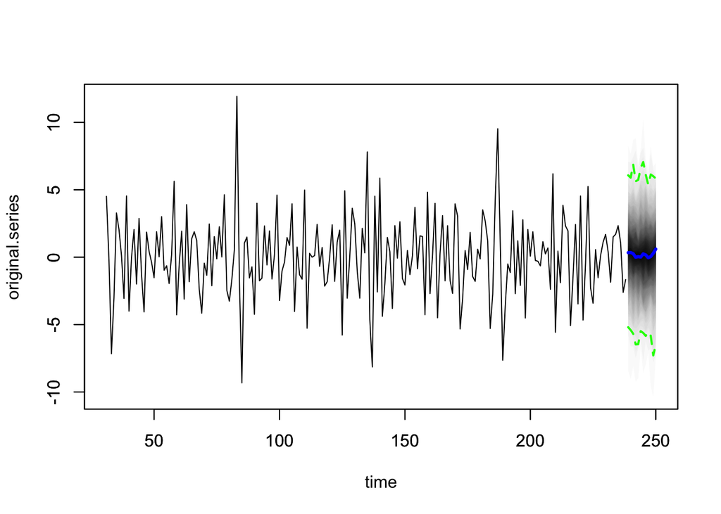

```r
fc <- predict(model, horizon = 12, burn = SuggestBurn(0.5, model))
plot(fc,
     interval.quantiles = c(.025, .975),
     plot.original = 208)
```

### Исследование производного временного ряда

Построим временной ряд $z_t = 0.5 + y_t +\epsilon_t$, где $\epsilon_t \sim N(0, \sigma_\epsilon), \sigma_\epsilon=0.1$, $y$ - исходный временной ряд. Также построим временной ряд $\hat{\epsilon}_t, \hat{\epsilon}_t \sim N(0, \sigma_\epsilon)$.

```r
sigma.eps = 0.1
z_t <- bind_rows(
    eps=arima.sim(list(0,0,0), n=length(df$Inc), sd=sigma.eps),
    y=df$Inc,
    eps.hat=arima.sim(list(0,0,0), n=length(df$Inc), sd=sigma.eps)
  ) %>%
  mutate(z = 0.5 + y + eps) %>%
  mutate
z_t %>% head()
```

```
## # A tibble: 6 x 4
##        eps      y eps.hat      z
##      <dbl>  <dbl>   <dbl>  <dbl>
## 1 -0.0117  -2.91  -0.119  -2.42
## 2  0.150   -0.751  0.130  -0.101
## 3  0.00722  1.72  -0.0467  2.23
## 4  0.0386  -1.44   0.0664 -0.906
## 5  0.0839   1.25   0.0435  1.83
## 6 -0.0797   2.18  -0.134   2.60
```

Построим BSTS модели для полученного временного ряда, используя значения $y_t$, $\epsilon_t$ и $\hat{\epsilon}_t$ в качестве дополнительных регрессоров. Построим модели с одним и двумя ожидаемыми значимыми предикторами.

```r
ss <- AddLocalLinearTrend(list(), z_t$z)
ss <- AddSeasonal(ss, z_t$z, nseasons = 52)
model1 <- bsts(z ~ .,
               state.specification = ss,
               niter = 500,
               expected.model.size=1,
               data = z_t,
               seed = 2020)
```

```
## =-=-=-=-= Iteration 0 Sun Apr 11 23:28:53 2021 =-=-=-=-=
## =-=-=-=-= Iteration 50 Sun Apr 11 23:28:55 2021 =-=-=-=-=
## =-=-=-=-= Iteration 100 Sun Apr 11 23:28:57 2021 =-=-=-=-=
## =-=-=-=-= Iteration 150 Sun Apr 11 23:28:59 2021 =-=-=-=-=
## =-=-=-=-= Iteration 200 Sun Apr 11 23:29:00 2021 =-=-=-=-=
## =-=-=-=-= Iteration 250 Sun Apr 11 23:29:02 2021 =-=-=-=-=
## =-=-=-=-= Iteration 300 Sun Apr 11 23:29:04 2021 =-=-=-=-=
## =-=-=-=-= Iteration 350 Sun Apr 11 23:29:05 2021 =-=-=-=-=
## =-=-=-=-= Iteration 400 Sun Apr 11 23:29:07 2021 =-=-=-=-=
## =-=-=-=-= Iteration 450 Sun Apr 11 23:29:09 2021 =-=-=-=-=
```

```r
model2 <- bsts(z ~ .,
               state.specification = ss,
               niter = 500,
               expected.model.size=2,
               data = z_t,
               seed = 2020)
```

```
## =-=-=-=-= Iteration 0 Sun Apr 11 23:29:12 2021 =-=-=-=-=
## =-=-=-=-= Iteration 50 Sun Apr 11 23:29:14 2021 =-=-=-=-=
## =-=-=-=-= Iteration 100 Sun Apr 11 23:29:16 2021 =-=-=-=-=
## =-=-=-=-= Iteration 150 Sun Apr 11 23:29:17 2021 =-=-=-=-=
## =-=-=-=-= Iteration 200 Sun Apr 11 23:29:19 2021 =-=-=-=-=
## =-=-=-=-= Iteration 250 Sun Apr 11 23:29:20 2021 =-=-=-=-=
## =-=-=-=-= Iteration 300 Sun Apr 11 23:29:22 2021 =-=-=-=-=
## =-=-=-=-= Iteration 350 Sun Apr 11 23:29:23 2021 =-=-=-=-=
## =-=-=-=-= Iteration 400 Sun Apr 11 23:29:25 2021 =-=-=-=-=
## =-=-=-=-= Iteration 450 Sun Apr 11 23:29:27 2021 =-=-=-=-=
```

Исследуем значимость регрессионных коэффициентов при предикторах с помощью графика значимости предикторов и графика, показывающего какой предиктор был наиболее значим в каждый момент времени. Построим данные граифики для модели с ожидаемым числом значимых предикторов, равным 1.

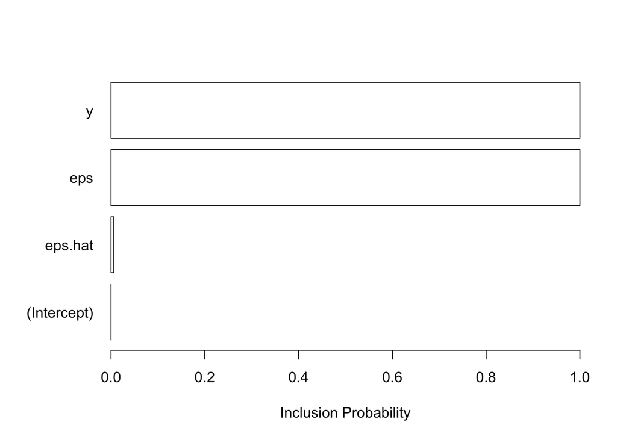

```r
plot(model1, "coef")
```

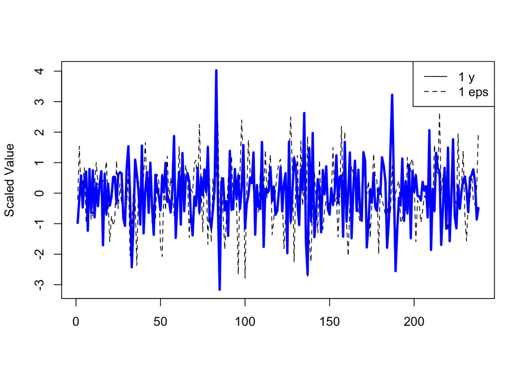

```r
plot(model1, "predictors")
```

```r
summary(model1)
```

```
## $residual.sd
## [1] 0.02820558
##
## $prediction.sd
## [1] 0.2836629
##
## $rsquare
## [1] 0.9999107
##
## $relative.gof
## [1] 0.9963232
##
## $size
##    Min. 1st Qu.  Median    Mean 3rd Qu.    Max.
##   2.000   2.000   2.000   2.006   2.000   3.000
##
## $coefficients
##                     mean          sd   mean.inc      sd.inc    inc.prob
## y           9.998019e-01 0.000916037 0.99980191 0.000916037 1.000000000
## eps         1.001314e+00 0.021150099 1.00131373 0.021150099 1.000000000
## eps.hat     9.803608e-05 0.001435769 0.01607792 0.012658680 0.006097561
## (Intercept) 0.000000e+00 0.000000000 0.00000000 0.000000000 0.000000000
```

Построим данные графики для модели с ожидаемым числом значимых предикторов, равным 2.

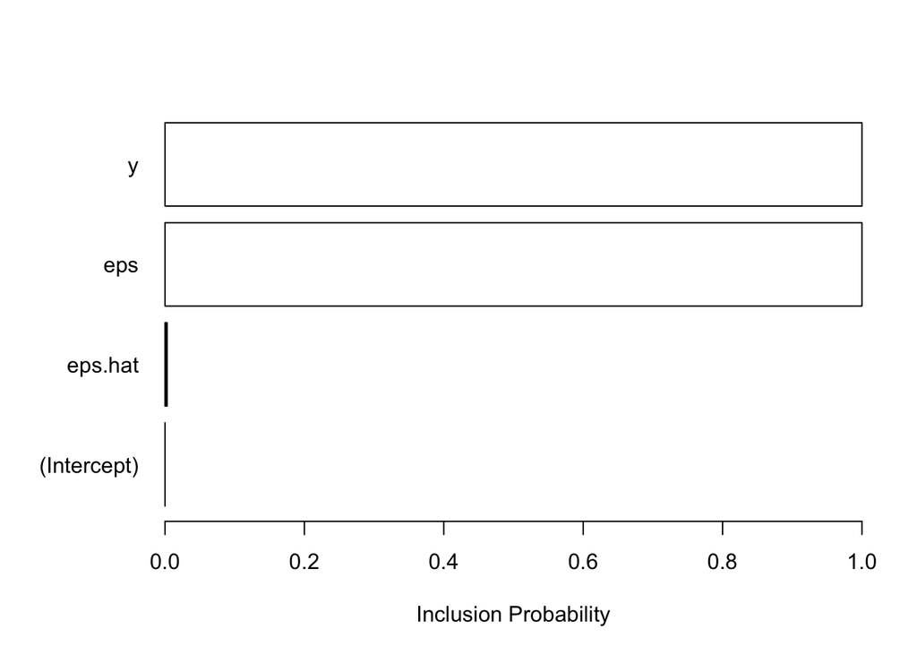

```r
plot(model2, "coef")
```

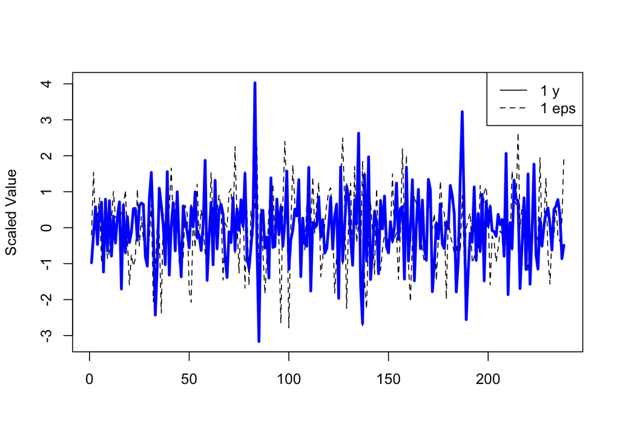

```r
plot(model2, "predictors")
```

```r
summary(model2)
```

```
## $residual.sd
## [1] 0.02816392
##
## $prediction.sd
## [1] 0.285199
##
## $rsquare
## [1] 0.999911
##
## $relative.gof
## [1] 0.9962833
##
## $size
##    Min. 1st Qu.  Median    Mean 3rd Qu.    Max.
##   2.000   2.000   2.000   2.003   2.000   3.000
##
## $coefficients
##                      mean           sd      mean.inc       sd.inc   inc.prob
## y            9.998367e-01 9.219323e-04  0.9998366803 0.0009219323 1.00000000
## eps          1.000621e+00 2.078854e-02  1.0006212980 0.0207885380 1.00000000
## eps.hat     -2.677218e-06 4.848648e-05 -0.0008781275 0.0000000000 0.00304878
## (Intercept)  0.000000e+00 0.000000e+00  0.0000000000 0.0000000000 0.00000000
```